# Statistical Modeling and Inference - Homework 4

Eric Bataller

```r
knitr::opts_chunk$set(message= FALSE, warning = FALSE)
```

In this question we are going to use topic modeling to understand how parliamentary speech varies by the gender of the MP. We will be working with a corpus of speeches made by legislators in the UK House of Commons in the 2014 calendar year. Specificaly, we’ll make use of Structural topic modeling.

Import libraries:

```r
library(readr)
library(quanteda)
library(quanteda.textplots) # complementary to quanteda, for visualization
library(topicmodels)
library(LDAvis)
library(stm)
library(knitr)
library(lda)
library(servr)
library(dplyr)
set.seed(5528) # set seed for reproductibility
PATH= 'C:/Users/ericb/Desktop/Data Science/BSE_Data_Science_master/Statistical Modeling and Inference/Part 2 - Clustering, PCA, LDA/Seminar5'
```

# 1 Load the data from the representatives:

```r
load(file.path(PATH,"data/hoc_speeches.Rdata"))
```

# 2 Data exploration

```r
#Remove repeated ones
speechesDF <- distinct(speeches, speech, .keep_all = TRUE)

sapply(speechesDF, class)
```

```
##        date        name       party      gender      speech      ntoken
##      "Date" "character" "character"    "factor" "character"   "integer"
```

```r
summary(speechesDF)
```

```
##       date                name              party              gender
##  Min.   :2014-01-06   Length:7139        Length:7139        female:1576
##  1st Qu.:2014-03-11   Class :character   Class :character   male  :5563
##  Median :2014-06-23   Mode  :character   Mode  :character
##  Mean   :2014-06-24
##  3rd Qu.:2014-10-21
##  Max.   :2014-12-18
##     speech              ntoken
##  Length:7139        Min.   :   1.0
##  Class :character   1st Qu.:  50.0
##  Mode  :character   Median :  80.0
##                     Mean   : 171.7
##                     3rd Qu.: 131.0
##                     Max.   :6342.0
```

```r
prop.table(table(speechesDF$party, speechesDF$gender),1)
```

```
##
##                        female       male
##   Conservative     0.14962406 0.85037594
##   Labour           0.37372916 0.62627084
##   Liberal Democrat 0.08695652 0.91304348
```

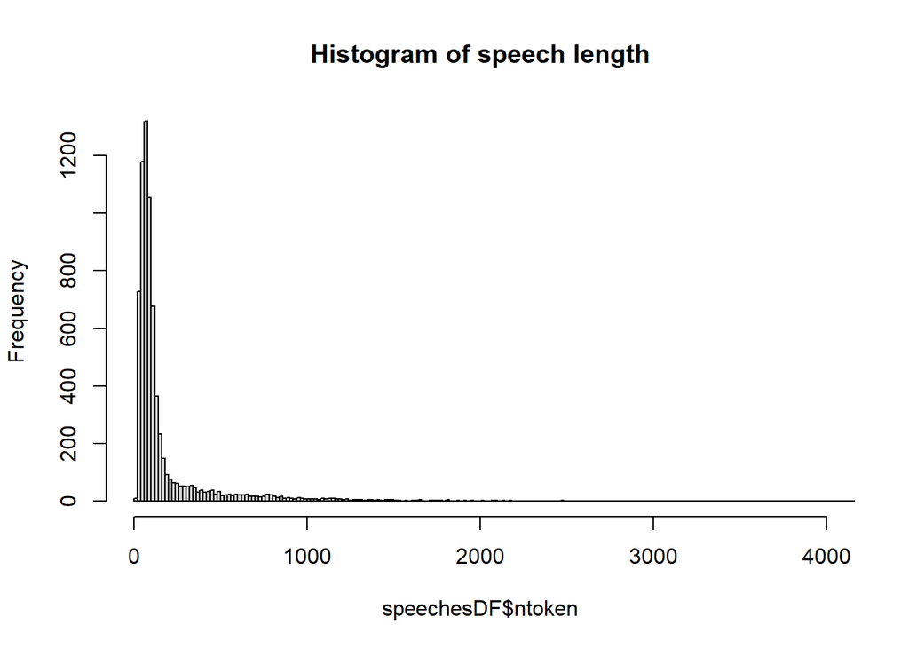

```r
speechesDF$ntoken <- ntoken(speechesDF$speech)
hist(speechesDF$ntoken, main = "Histogram of speech length", xlim = c(0, 4000), breaks = 300)
```

# 3 Use the functions in the `quanteda` package to turn this data into a `corpus` object.

We create the corpus and retain only documents with a length between 50 and 800.

```r
#Create corpus:
speeches_Corpus <- corpus(speechesDF$speech, docvars = speechesDF)

#Filtering doc lenght:
ntokens_corpus <- ntoken(speeches_Corpus)
docs_length50_800 <- names(ntokens_corpus[(ntokens_corpus>=50) & (ntokens_corpus<=800)])
speeches_Corpus <- speeches_Corpus[names(speeches_Corpus) %in% docs_length50_800]

#Print summary:
summary(speeches_Corpus, n = 4) #summary() from quanteda package. We only print [,0:4] to avoid printing the speech column
```

```
## Corpus consisting of 5595 documents, showing 4 documents:
##
##   Text Types Tokens Sentences       date           name        party gender
##  text1    78    109         5 2014-03-13      Lyn Brown       Labour female
##  text2    66     97         8 2014-09-09  Cheryl Gillan Conservative female
##  text3    41     59         3 2014-04-08   James Morris Conservative   male
##  text4    52     68         3 2014-12-08 Rehman Chishti Conservative   male
##                                                                                                                                                                                                                                                                                                          …
##  I welcome my hon. Friend s statement. As the report makes clear, procurement is inextricably linked with local government aspirations relating to the pursuit of social value and community benefit, collaboration to obtain best value for money, greater transparency and a better understanding of ri…
##                                                                                                                                                                                                My hon. Friend makes a very valid point.  The hon. Member for Blackley and Broughton (Graham Stringer)  kn…
##                                                                                                                                                                                                                                                                                                          …
##                                                                                                                                                                                                                                                                                              I thank the …
##  ntoken
##     109
##      97
##      59
##      68
```

```r
head(speeches_Corpus)
```

```
## Corpus consisting of 6 documents and 6 docvars.
## text1 :
## "I welcome my hon. Friend s statement. As the report makes cl..."
##
## text2 :
## "My hon. Friend makes a very valid point.  The hon. Member fo..."
##
## text3 :
## "Under this Government, local authorities will be able to ret..."
##
## text4 :
## "I thank the Secretary of State for that answer. I welcome th..."
##
## text6 :
## "I beg to move,  That this House has considered rural communi..."
##
## text7 :
## "The hon. Gentleman says that he is looking for evidence that..."
```

List of common words we will remove from our texts.

```r
custom_list_stopwords <- c(stopwords("en"), 'also', 'may','can','hon','govern','will', 'welcome','go','make','s')
```

# 4 Turn this corpus into a tokens object and then into a document-feature matrix.

```r
speechDFM_filtered <- tokens(speeches_Corpus, remove_punct = TRUE,
                                    remove_symbols = TRUE, remove_numbers = TRUE) %>%
                      tokens_remove(custom_list_stopwords) %>% #Remove words contained in custom_list
                      tokens_wordstem() %>%
                      tokens_remove(custom_list_stopwords) %>% #Remove potential stemmed words in custom_list
                      tokens_ngrams(n = c(1, 2)) %>% #include all the individual words and the groups of 2 words
                      dfm() %>%
                      dfm_tolower() %>%
                      dfm_trim(min_termfreq = 5, min_docfreq = 0.0025, docfreq_type = "prop") #Remove unfrequent words
speechDFM_filtered
```

```
## Document-feature matrix of: 5,595 documents, 3,249 features (98.50% sparse) and 6 docvars.
##        features
## docs    friend statement report clear procur link local aspir relat social
##   text1      1         1      1     1      2    1     4     1     1      1
##   text2      1         0      0     0      0    0     0     0     0      0
##   text3      0         0      0     0      0    0     4     0     0      0
##   text4      0         0      0     0      0    1     0     0     0      0
##   text6      3         0      1     0      0    0     4     0     1      0
##   text7      0         0      0     0      0    0     0     0     0      0
## [ reached max_ndoc ... 5,589 more documents, reached max_nfeat ... 3,239 more features ]
```

Plot the words by overall frequency:

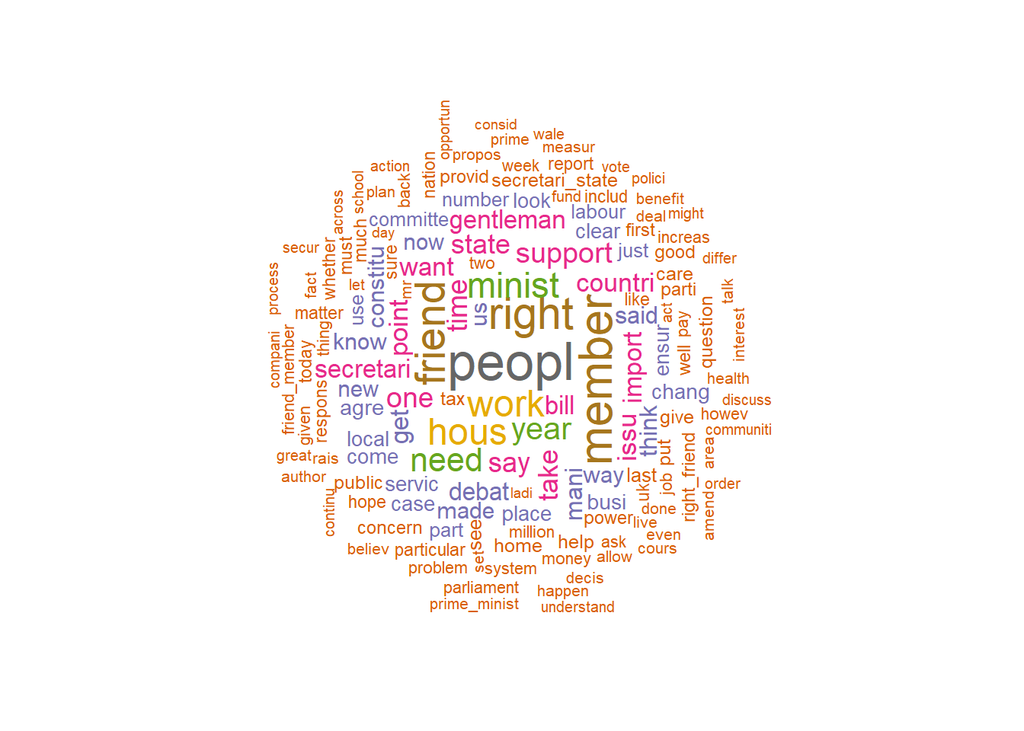

```r
textplot_wordcloud(speechDFM_filtered, random_order = FALSE, rotation = 0.25,
    color = RColorBrewer::brewer.pal(8, "Dark2"),max_words =150,max_size = 3)
```

# 5 Run a structural topic model for this corpus, using the gender variable in the topic prevalence argument. Use the stm function to do this.

```r
K <- 20
fitted_stm <- stm(documents = speechDFM_filtered,
              data = docvars(speechDFM_filtered),
              prevalence = ~gender,
              K = K, seed = 123, verbose = TRUE)
```

# 6 Specify and estimate the stm model:

Estimated topic model:

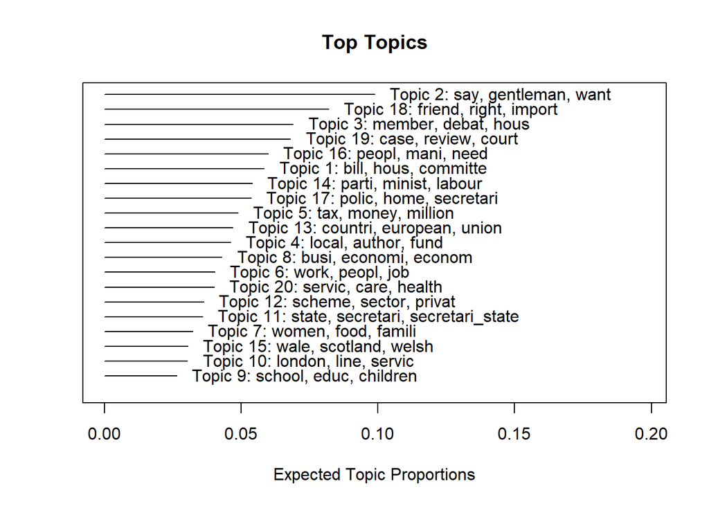

```r
plot(fitted_stm)
```

Top words from each topic:

```r
topic_labels <- labelTopics(fitted_stm)
top_words <- apply(topic_labels$prob, 1, function(x) paste(x, collapse=", "))
print(top_words)
```

```
##  [1] "bill, hous, committe, amend, legisl, claus, new"
##  [2] "say, gentleman, want, think, said, way, know"
##  [3] "member, debat, hous, friend_member, mr, friend, time"
##  [4] "local, author, fund, area, council, communiti, local_author"
##  [5] "tax, money, million, year, benefit, cost, spend"
##  [6] "work, peopl, job, employ, wage, pay, unemploy"
##  [7] "women, food, famili, child, inquiri, number, abus"
##  [8] "busi, economi, econom, industri, bank, invest, small"
##  [9] "school, educ, children, young, young_peopl, teacher, need"
## [10] "london, line, servic, rail, palestinian, transport, west"
## [11] "state, secretari, secretari_state, energi, price, consum, market"
## [12] "scheme, sector, privat, compani, pension, home, rent"
## [13] "countri, european, union, right, eu, british, intern"
## [14] "parti, minist, labour, prime, prime_minist, elect, opposit"
## [15] "wale, scotland, welsh, northern, power, ireland, england"
## [16] "peopl, mani, need, problem, constitu, countri, get"
## [17] "polic, home, secretari, minist, support, action, crime"
## [18] "friend, right, import, right_friend, agre, work, issu"
## [19] "case, review, court, ensur, justic, individu, system"
## [20] "servic, care, health, nhs, patient, hospit, trust"
```

Top three documents associated with each topic:

```r
top_docs <- apply(fitted_stm$theta, 2, function(x) order(x, decreasing = T)[1:3])
top_docs
```

```
##      [,1] [,2] [,3] [,4] [,5] [,6] [,7] [,8] [,9] [,10] [,11] [,12] [,13] [,14]
## [1,]  848 1187 4452 2358 4421 3339 1135   63 1935  1913  3402  3819  1080   402
## [2,] 3267 2927 3143  167 4528 3656 1299 1453 3218   141  4178   694  4592  1591
## [3,] 3734 1350 2586 5015 4104 2976 5461 1478  228  4608  4859  2276  1081  2344
##      [,15] [,16] [,17] [,18] [,19] [,20]
## [1,]  3995  3698  5534  4861  1313  2852
## [2,]   601  2864  4596  2311   699  4620
## [3,]   373   817  4072  2988   211  3642
```

Report the top speeches for one selected topic:

```r
top_busi_docs <- top_docs[,grep("busi",top_words)]
docvars(speechDFM_filtered)[top_busi_docs,"speech"]
```

```
## [1] "There is great potential for business reshoring to Britain. We surveyed manufacturing small and medium-sized enterprises and found that 11% have reshored some production to the UK in the past 12 months. The Automotive Council has identified  3 billion of additional sourcing opportunities. Bu…
## [2] "Our  1 billion business rates support package includes a  1,000 discount for smaller shops, pubs and restaurants. That will benefit more than 300,000 premises in England, including 430 in Cherwell and 580 in Dover. We are also doubling small business rate relief for a further year, which wil…
## [3] "Well, the good news is that the rate of investment in energy infrastructure has doubled under this Government; there has been  45 billion of investment so far, but we have a  100 billion programme because of the massive underinvestment that occurred in the previous decade. It is regrettable …
```

We can see that the 3 speeches are related to business and economy in general, which seems to be sort of the underlying theme of topic number 8.

# 7 Use the estimateEffect and plot.estimateEffect functions in the stm package to estimate the effect of MP gender on topic usage.

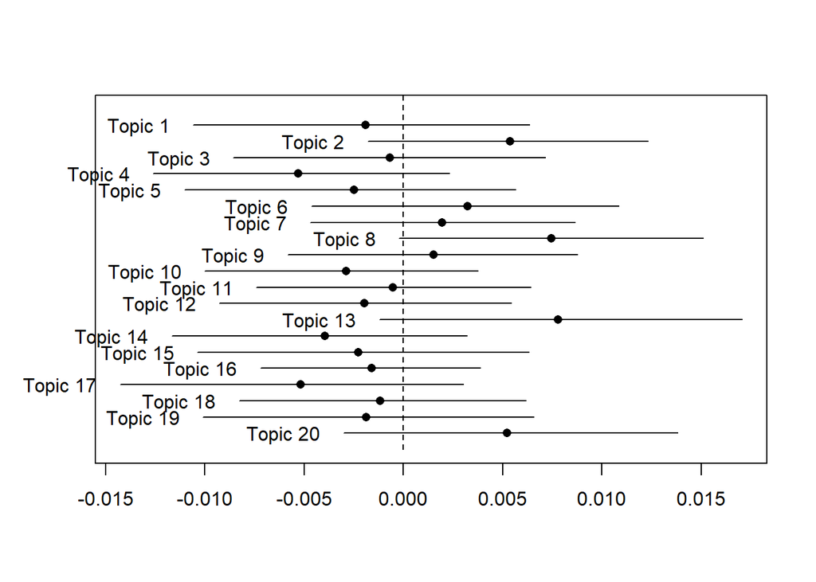

```r
est_gender_effect <- estimateEffect(~gender, fitted_stm, metadata = docvars(speechDFM_filtered))
plot.estimateEffect(est_gender_effect, "gender", method = "difference",
                    cov.value1 = "female", cov.value2 = "male",
                    labeltype = "custom", n = 2, verbose.labels = F, custom.labels = sprintf("Topic %s", 1:20),
                    model = fitted_stm)
```

On which topics are women, on average, more active?

We can see the differences on activity of each topics. Specifically, some of the ones that stand out by the greater activity on female MP are:

Topic 20: “servic, care, health, nhs, patient, hospit, trust”… Topic 13: “countri, european, union, right, eu, british, intern”… Topic 8: “busi, economi, econom, industri, bank, invest, small”…

Nonetheless, none of the CI reports a “greater than 0 difference between the probability of each topic”. Thus, the differences observed are not so significant.